—title: “Emmeans alternative - PP75 FM2.5” author: “Valerie Martin” date: “10/7/2019” output: html_document —

title: "Skypilot Selection Analyses__PP_75 - SM_2.5 Part 2" author: “Valerie Martin” date: “8/25/2019” output: word_document: fig_height: 2.25 fig_width: 3 html_document: df_print: paged —

## Skypilot Selection Analyse with 75% Pollination Percentage and 2.5 Seed Maturity

### Supplementation Experiment

Niki: “Can’t use cumberland pass (no supplmement seeds were successfully collected…triple checking that). Marginal interaction effect: total seeds per plant increased with supplementation of skunky, but not sweet, flowers. Sweet has this weird relationship where sup seedset goes up with flower size. Jake swears size differences shouldn’t have influenced the effectiveness of the treatment.”

#### Sweet morph only

Niki: “no effect of habitat => remove no treatment effect, but Candi saw this in some years - might it relate to weaking selection?”

Niki: “Extract least squares mean which accounts for random effect”

```r
fit<-lme(sqrt(Total.SeedsPerPlant)~Treatment, random=~1|Site, data=fruit.sw.np, method="ML", na.action=na.omit)
anova.lme(fit)
```

```
##             numDF denDF   F-value p-value
## (Intercept)     1    28 199.11010  <.0001
## Treatment       1    28   0.27848  0.6019
```

```r
#type="response" causes the emmeans and contrasts tables to backtransform from the sqrt and show confidence intervals and p-values that represent the backtransformed variables
marginal = emmeans(fit, specs=pairwise ~ Treatment, type = "response")
marginal$emmeans
```

```
##  Treatment       response    SE df lower.CL upper.CL
##  Natural             44.1  7.25  1        0      184
##  Supplementation     37.3 10.43  1        0      287
##
## d.f. method: containment
## Confidence level used: 0.95
## Intervals are back-transformed from the sqrt scale
```

```r
marginal$contrasts
```

```
##  contrast                  estimate   SE df t.ratio p.value
##  Natural - Supplementation    0.535 1.01 28 0.528   0.6019
```

```r
marginal$contrasts %>%
     summary(infer = TRUE)
```

```
##  contrast                  estimate   SE df lower.CL upper.CL t.ratio
##  Natural - Supplementation    0.535 1.01 28    -1.54     2.61 0.528
##  p.value
##  0.6019
##
## Confidence level used: 0.95
```

```r
#putting the data into a data frame so that we can plot it
marginal_contrasts = marginal$contrasts %>%
     summary() %>%
     as.data.frame()
marginal_contrasts
```

```
##                    contrast  estimate       SE df   t.ratio   p.value
## 1 Natural - Supplementation 0.5345919 1.013029 28 0.5277162 0.6018536
```

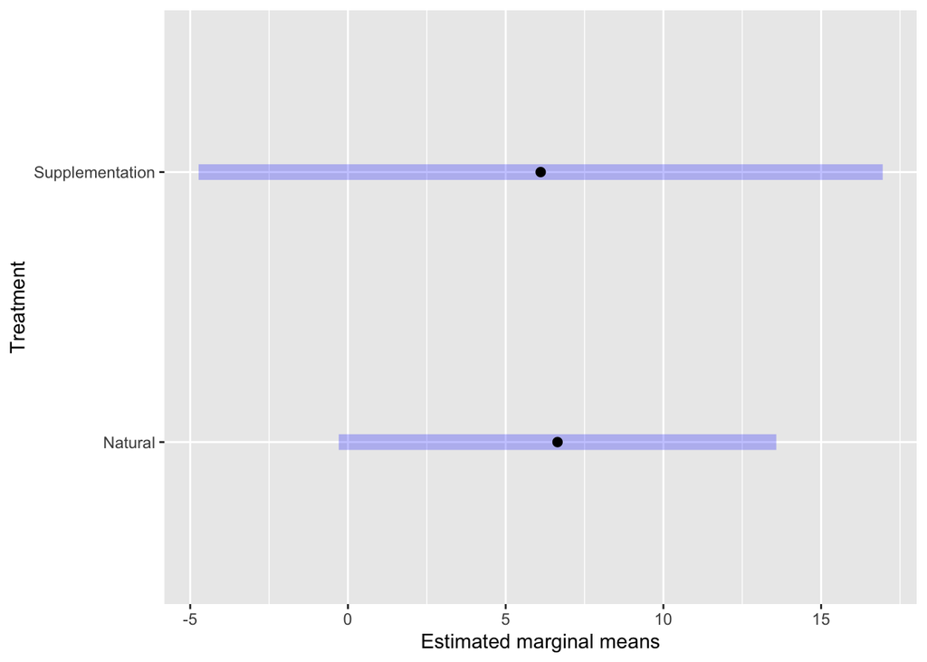

```r
marginal_sqrt = emmeans(fit, specs=pairwise ~ Treatment)
#plot of the sqrt transformed emmeans
plot(marginal_sqrt, xlab="Estimated marginal means")
```

Plots (not controlling for random effects)

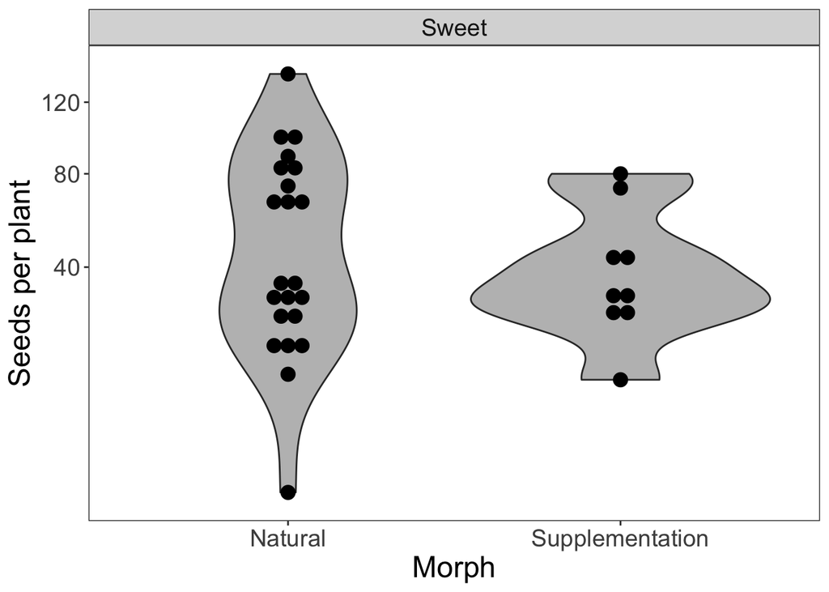

```r
ggplot(fruit.sw.np, aes(Treatment,Total.SeedsPerPlant)) +
  geom_violin(fill='gray') +
  geom_dotplot(binaxis='y', stackdir='center', dotsize=1)  +
  facet_wrap(~Morph) +
  scale_y_continuous(trans="sqrt") +
  ylab("Seeds per plant") +
  xlab("Morph") +
  theme_bw() +
  theme(panel.grid.major = element_blank(), panel.grid.minor = element_blank(), text = element_text(size=18))
```

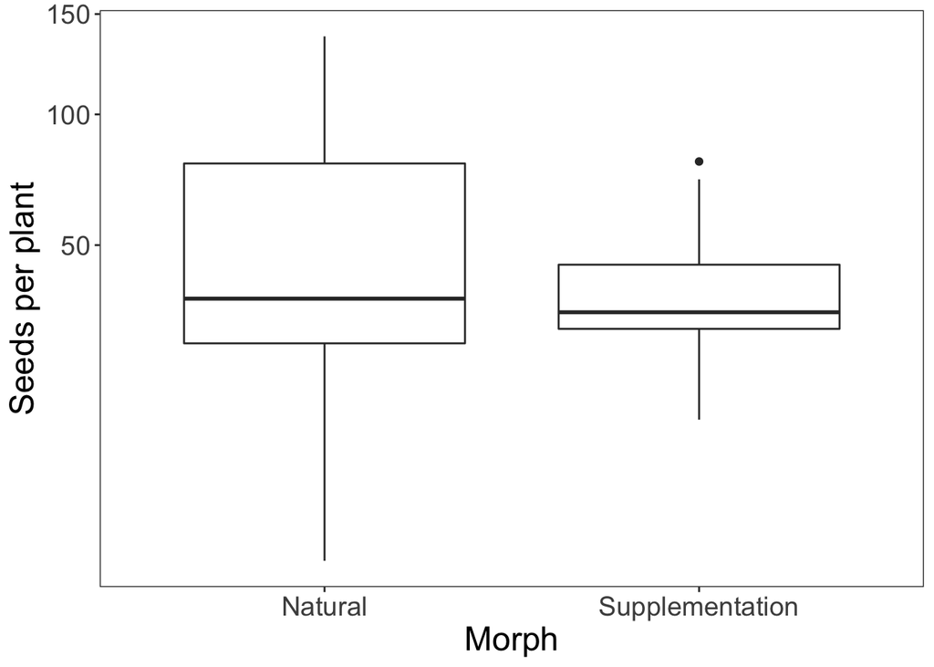

```r
ggplot(fruit.sw.np, aes(Treatment,Total.SeedsPerPlant)) +
  geom_boxplot() +
  scale_y_continuous(trans="sqrt") +
  ylab("Seeds per plant") +
  xlab("Morph") +
  theme_bw() +
  theme(panel.grid.major = element_blank(), panel.grid.minor = element_blank(), text = element_text(size=18))
```

With habitat effects: Val: “For the two second ANOVA tables, I am getting an error regarding the use of lm() instead of lme() - why are we using lm() and why is it not computing into an ANOVA table?”

```r
fit<-lme(sqrt(Total.SeedsPerPlant)~Treatment, random=~1|Site/Habitat, data=fruit.sw.np, method="ML", na.action=na.omit)
anova.lme(fit)
```

```
##             numDF denDF   F-value p-value
## (Intercept)     1    26 166.63119  <.0001
## Treatment       1    26   0.33518  0.5676
```

```r
fit<-lm(sqrt(Total.SeedsPerPlant)~Habitat, data=fruit.sw.np)

fit<-lme(sqrt(Total.SeedsPerPlant)~Treatment*Habitat, random=~1|Site, data=fruit.sw.np, method="ML", na.action=na.omit)
anova.lme(fit)
```

```
##                   numDF denDF   F-value p-value
## (Intercept)           1    26 197.26667  <.0001
## Treatment             1    26   0.27591  0.6038
## Habitat               1    26   1.69895  0.2039
## Treatment:Habitat     1    26   0.03256  0.8582
```

```r
fit<-lm(sqrt(Total.SeedsPerPlant)~Site, data=fruit.sw.np)
```

Both Morphs

```r
fit<-lme(sqrt(Total.SeedsPerPlant)~Treatment*Morph, random=~1|Site, data=fruit.np, method="ML", na.action=na.omit)
anova.lme(fit)
```

```
##                 numDF denDF  F-value p-value
## (Intercept)         1    50 415.3788  <.0001
## Treatment           1    50   0.4960  0.4845
## Morph               1    50   0.1446  0.7053
## Treatment:Morph     1    50   2.1199  0.1516
```

```r
marginal_both = emmeans(fit, specs=pairwise ~ Treatment, type = "response")
```

```
## NOTE: Results may be misleading due to involvement in interactions
```

```r
marginal_both$emmeans
```

```
##  Treatment       response   SE df lower.CL upper.CL
##  Natural             40.9 5.40  1     1.06      138
##  Supplementation     47.0 7.44  1     0.00      189
##
## Results are averaged over the levels of: Morph
## d.f. method: containment
## Confidence level used: 0.95
## Intervals are back-transformed from the sqrt scale
```

```r
marginal_both$contrasts
```

```
##  contrast                  estimate    SE df t.ratio p.value
##  Natural - Supplementation   -0.466 0.687 50 -0.678  0.5009
##
## Results are averaged over the levels of: Morph
```

```r
marginal_both_sqrt = emmeans(fit, specs=pairwise ~ Treatment)
```

```
## NOTE: Results may be misleading due to involvement in interactions
```

```r
marginal_both$contrasts %>%
     summary(infer = TRUE)
```

```
##  contrast                  estimate    SE df lower.CL upper.CL t.ratio
##  Natural - Supplementation   -0.466 0.687 50    -1.85    0.914 -0.678
##  p.value
##  0.5009
##
## Results are averaged over the levels of: Morph
## Confidence level used: 0.95
```

```r
#putting the data into a data frame so that we can plot it
marginal_contrasts2 = marginal_both$contrasts %>%
     summary() %>%
     as.data.frame()
marginal_contrasts2
```

```
##                    contrast   estimate        SE df   t.ratio   p.value
## 1 Natural - Supplementation -0.4658238 0.6870983 50 -0.677958 0.5009238
```

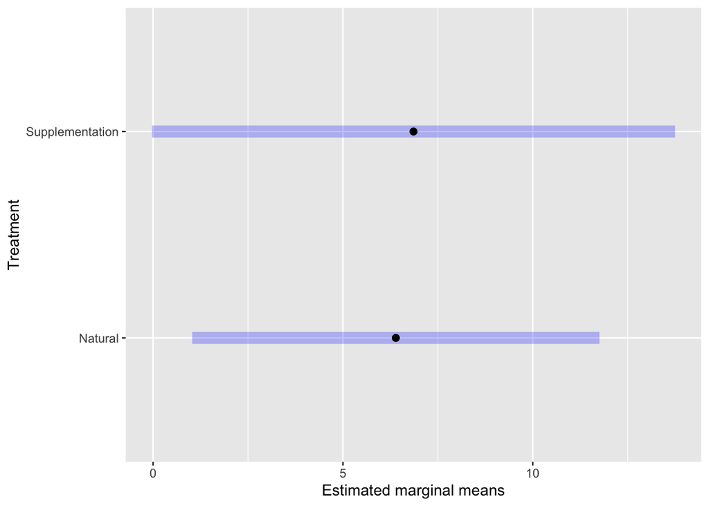

```r
#plot of the sqrt transformed emmeans
plot(marginal_both_sqrt, xlab="Estimated marginal means")
```

plot (not controlling for random effects)

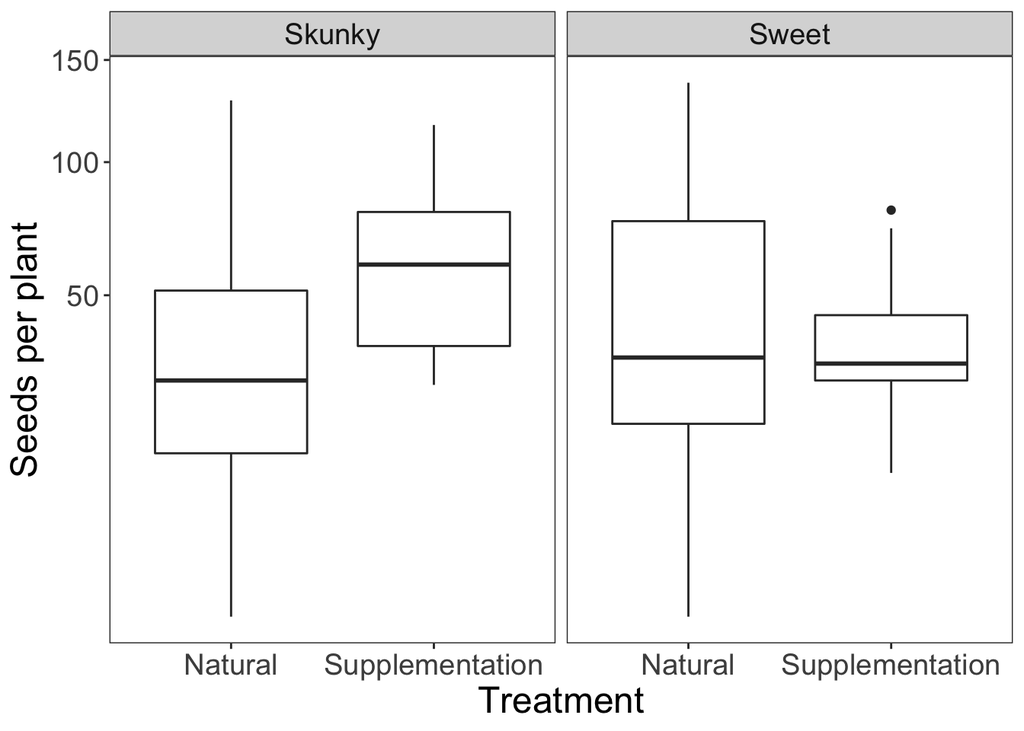

```r
ggplot(fruit.sm, aes(Treatment,Total.SeedsPerPlant)) +
  geom_boxplot() +
  scale_y_continuous(trans="sqrt") +
  ylab("Seeds per plant") +
  facet_wrap(~Morph) +
  theme_bw() +
  theme(panel.grid.major = element_blank(), panel.grid.minor = element_blank(), text = element_text(size=18))
```

with habitat effects:

```r
fit<-lme(sqrt(Total.SeedsPerPlant)~Treatment*Habitat, random=~1|Site, data=fruit.np, method="ML", na.action=na.omit)
anova.lme(fit)
```

```
##                   numDF denDF  F-value p-value
## (Intercept)           1    50 411.6173  <.0001
## Treatment             1    50   0.4915  0.4865
## Habitat               1    50   0.5791  0.4502
## Treatment:Habitat     1    50   1.2031  0.2780
```